# Plant Seedlings Classification

### Image size reduction for faster computation

The given dataset has images of the pixel size - 128 x 128, which will be computationally expensive when we build complex CNN models. Hence, we will reduce the image size to 64 * 64 for faster computation

```python
# Decreasing image size to 64 x 64 for faster computation
images_decreased=[]
height = 64
width = 64
dimensions = (width, height)
for i in range(len(images)):
  images_decreased.append( cv2.resize(images[i], dimensions, interpolation=cv2.INTER_LINEAR))
```

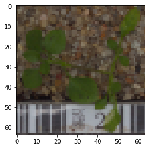

```python
plt.imshow(images_decreased[1500])
```

### Applying Gaussian Blur to reduce noise

```python
# Applying Gaussian Blur to denoise the images
images_gb=[]
for i in range(len(images)):
  # gb[i] = cv2.cvtColor(images[i], cv2.COLOR_BGR2RGB)
  images_gb.append(cv2.GaussianBlur(images[i], ksize =(3,3),sigmaX =  0))
```

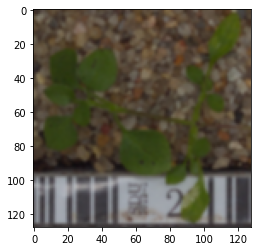

```python
plt.imshow(images_gb[1500])
```

### Splitting the data

We already saw that the data has very imbalanced Y values - which may reduce the accuracy. We will try and build the base model and then develop a strategy to deal with class imbalance

```python
from sklearn.model_selection import train_test_split
X_temp, X_test, y_temp, y_test = train_test_split(np.array(images_decreased),labels , test_size=0.1, random_state=42,stratify=labels)
X_train, X_val, y_train, y_val = train_test_split(X_temp,y_temp , test_size=0.1, random_state=42,stratify=y_temp)
```

```python
print(X_train.shape,y_train.shape)
print(X_val.shape,y_val.shape)
print(X_test.shape,y_test.shape)
```

```
(3847, 64, 64, 3) (3847, 1)
(428, 64, 64, 3) (428, 1)
(475, 64, 64, 3) (475, 1)
```

Thus, after splitting the data, the training set now has 3847 images, the validation set has 428 images and the testing set has 475 images

### One Hot Encoding

Since the output variable in our case study has 12 types, we will do one hot encoding to split the output Y to 12 values for each of the current Y value - making it all 0s for the one's that are not true and making it 1 for the actual Y value

```python
# Convert labels from names to one hot vectors.
# We have already used encoding methods like onehotencoder and labelencoder earlier so now we will be using a new encoding method called labelBinarizer.
# Labelbinarizer works similar to onehotencoder

from sklearn.preprocessing import LabelBinarizer
enc = LabelBinarizer()
y_train_encoded = enc.fit_transform(y_train)
y_val_encoded=enc.transform(y_val)
y_test_encoded=enc.transform(y_test)
```

### Normalizing

Since the pixel values are spread from 0 to 255, for when the pixel values are greater there is a chance of errors and hence to reduce such errors, we will normalize the pixel values by dividing those by 255 to make the pixel values between 0 and 1. Thus all the output after the operation on these pixel values does not blow up the code

```python
# Normalizing the image pixels
X_train_normalized = X_train.astype('float32')/255.0
X_val_normalized = X_val.astype('float32')/255.0
X_test_normalized = X_test.astype('float32')/255.0
```

## Base CNN Model

```python
# Clearing backend
from tensorflow.keras import backend
backend.clear_session()
```

```python
# Fixing the seed for random number generators
import random
np.random.seed(42)
random.seed(42)
tf.random.set_seed(42)
```

In the following CNN model, we have the Convulational layer consisting of 2 blocks - 1st block with 64 layers of 3 x 3 filter following by a max pooling and the 2nd block with 32 layers of 3 x 3 filter with padding done such a way not to reduce the pixel size after the convolution operation on both the blocks.

This convolution layer is then flattened and then the Dense layers are connected with 16 layers to 12 layers, since the output on our case should be of 12 types with each layer having ReLu activation function, because we should not / would not need negative values on our output and softmax activation on the final layer.

```python
# Intializing a sequential model
model = Sequential()

# Adding first conv layer with 64 filters and kernel size 3x3 , padding 'same' provides the output size same as the input size
# Input_shape denotes input image dimension of images
model.add(Conv2D(64, (3, 3), activation='relu', padding="same", input_shape=(64, 64, 3)))

# Adding max pooling to reduce the size of output of first conv layer
model.add(MaxPooling2D((2, 2), padding = 'same'))

model.add(Conv2D(32, (3, 3), activation='relu', padding="same"))
model.add(MaxPooling2D((2, 2), padding = 'same'))

# flattening the output of the conv layer after max pooling to make it ready for creating dense connections
model.add(Flatten())

# Adding a fully connected dense layer with 100 neurons
model.add(Dense(16, activation='relu'))
model.add(Dropout(0.3))
# Adding the output layer with 10 neurons and activation functions as softmax since this is a multi-class classification problem
model.add(Dense(12, activation='softmax'))

# Using SGD Optimizer
# opt = SGD(learning_rate=0.01, momentum=0.9)
# opt=Adam()
# Compile model
# model.compile(optimizer=opt, loss=tf.keras.losses.SparseCategoricalCrossentropy(from_logits=True), metrics=['accuracy'])

# Generating the summary of the model
model.summary()
```

```
Model: "sequential_1"
_________________________________________________________________
 Layer (type)                Output Shape              Param #
=================================================================
 conv2d_2 (Conv2D)           (None, 64, 64, 64)        1792

 max_pooling2d_2 (MaxPooling  (None, 32, 32, 64)       0
 2D)

 conv2d_3 (Conv2D)           (None, 32, 32, 32)        18464

 max_pooling2d_3 (MaxPooling  (None, 16, 16, 32)       0
 2D)

 flatten_1 (Flatten)         (None, 8192)              0

 dense_2 (Dense)             (None, 16)                131088

 dropout_1 (Dropout)         (None, 16)                0

 dense_3 (Dense)             (None, 12)                204

=================================================================
Total params: 151,548
Trainable params: 151,548
Non-trainable params: 0
_________________________________________________________________
```

Therefore, there are a total of 151,548 training weights

```python
model.compile(optimizer='adam', loss='categorical_crossentropy', metrics=['accuracy'])
```

```python
history_1 = model.fit(
            X_train_normalized, y_train_encoded,
            epochs=30,
            validation_data=(X_val_normalized,y_val_encoded),
            batch_size=32,
            verbose=2
            )
```

```
121/121 - 2s - loss: 2.4632 - accuracy: 0.1058 - val_loss: 2.4314 - val_accuracy: 0.1379 - 2s/epoch - 19ms/step
121/121 - 1s - loss: 2.4121 - accuracy: 0.1713 - val_loss: 2.3619 - val_accuracy: 0.2290 - 633ms/epoch - 5ms/step
121/121 - 1s - loss: 2.3234 - accuracy: 0.2038 - val_loss: 2.2030 - val_accuracy: 0.2570 - 640ms/epoch - 5ms/step
121/121 - 1s - loss: 2.2590 - accuracy: 0.2152 - val_loss: 2.1564 - val_accuracy: 0.2570 - 672ms/epoch - 6ms/step
121/121 - 1s - loss: 2.2051 - accuracy: 0.2202 - val_loss: 2.0801 - val_accuracy: 0.2617 - 631ms/epoch - 5ms/step
121/121 - 1s - loss: 2.1858 - accuracy: 0.2191 - val_loss: 2.0356 - val_accuracy: 0.2710 - 656ms/epoch - 5ms/step
121/121 - 1s - loss: 2.1336 - accuracy: 0.2254 - val_loss: 2.0364 - val_accuracy: 0.2874 - 651ms/epoch - 5ms/step
121/121 - 1s - loss: 2.1068 - accuracy: 0.2316 - val_loss: 1.9596 - val_accuracy: 0.2850 - 644ms/epoch - 5ms/step
121/121 - 1s - loss: 2.0916 - accuracy: 0.2355 - val_loss: 1.9808 - val_accuracy: 0.3131 - 643ms/epoch - 5ms/step
121/121 - 1s - loss: 2.0502 - accuracy: 0.2508 - val_loss: 1.9103 - val_accuracy: 0.3154 - 635ms/epoch - 5ms/step
121/121 - 1s - loss: 2.0379 - accuracy: 0.2506 - val_loss: 1.9004 - val_accuracy: 0.3224 - 639ms/epoch - 5ms/step
121/121 - 1s - loss: 2.0177 - accuracy: 0.2555 - val_loss: 1.8632 - val_accuracy: 0.3224 - 657ms/epoch - 5ms/step
121/121 - 1s - loss: 2.0116 - accuracy: 0.2592 - val_loss: 1.8394 - val_accuracy: 0.3364 - 635ms/epoch - 5ms/step
121/121 - 1s - loss: 1.9973 - accuracy: 0.2625 - val_loss: 1.8096 - val_accuracy: 0.3341 - 678ms/epoch - 6ms/step
121/121 - 1s - loss: 1.9831 - accuracy: 0.2607 - val_loss: 1.8517 - val_accuracy: 0.3481 - 656ms/epoch - 5ms/step
121/121 - 1s - loss: 1.9775 - accuracy: 0.2703 - val_loss: 1.7919 - val_accuracy: 0.3458 - 643ms/epoch - 5ms/step
121/121 - 1s - loss: 1.9749 - accuracy: 0.2633 - val_loss: 1.8336 - val_accuracy: 0.3481 - 652ms/epoch - 5ms/step
121/121 - 1s - loss: 1.9600 - accuracy: 0.2740 - val_loss: 1.7640 - val_accuracy: 0.3364 - 633ms/epoch - 5ms/step
121/121 - 1s - loss: 1.9570 - accuracy: 0.2667 - val_loss: 1.7658 - val_accuracy: 0.3598 - 649ms/epoch - 5ms/step
121/121 - 1s - loss: 1.9443 - accuracy: 0.2807 - val_loss: 1.7875 - val_accuracy: 0.3902 - 653ms/epoch - 5ms/step
121/121 - 1s - loss: 1.9503 - accuracy: 0.2745 - val_loss: 1.7720 - val_accuracy: 0.3575 - 639ms/epoch - 5ms/step
121/121 - 1s - loss: 1.9205 - accuracy: 0.2844 - val_loss: 1.7650 - val_accuracy: 0.3575 - 655ms/epoch - 5ms/step
121/121 - 1s - loss: 1.9234 - accuracy: 0.2813 - val_loss: 1.7392 - val_accuracy: 0.3808 - 646ms/epoch - 5ms/step
121/121 - 1s - loss: 1.9025 - accuracy: 0.2862 - val_loss: 1.6941 - val_accuracy: 0.3692 - 625ms/epoch - 5ms/step
121/121 - 1s - loss: 1.9143 - accuracy: 0.2896 - val_loss: 1.7096 - val_accuracy: 0.3879 - 673ms/epoch - 6ms/step
121/121 - 1s - loss: 1.8938 - accuracy: 0.2922 - val_loss: 1.7086 - val_accuracy: 0.4065 - 634ms/epoch - 5ms/step
121/121 - 1s - loss: 1.8980 - accuracy: 0.2846 - val_loss: 1.7140 - val_accuracy: 0.3995 - 648ms/epoch - 5ms/step
121/121 - 1s - loss: 1.8878 - accuracy: 0.2961 - val_loss: 1.7369 - val_accuracy: 0.3879 - 661ms/epoch - 5ms/step
121/121 - 1s - loss: 1.8661 - accuracy: 0.3031 - val_loss: 1.7009 - val_accuracy: 0.4065 - 641ms/epoch - 5ms/step
121/121 - 1s - loss: 1.8498 - accuracy: 0.3060 - val_loss: 1.6596 - val_accuracy: 0.4112 - 662ms/epoch - 5ms/step
```

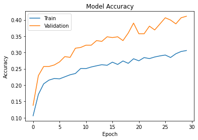

```python
plt.plot(history_1.history['accuracy'])
plt.plot(history_1.history['val_accuracy'])
plt.title('Model Accuracy')
plt.ylabel('Accuracy')
plt.xlabel('Epoch')
plt.legend(['Train', 'Validation'], loc='upper left')
plt.show()
```

```python
accuracy = model.evaluate(X_test_normalized, y_test_encoded, verbose=2)
```

```
15/15 - 0s - loss: 1.6523 - accuracy: 0.3895 - 101ms/epoch - 7ms/step
```

Looking at the accuracy on the test data, we can see that this model has an accuracy of 38.95% on the unseen / testing data

```python
# Here we would get the output as probablities for each category
y_pred=model.predict(X_test_normalized)
```

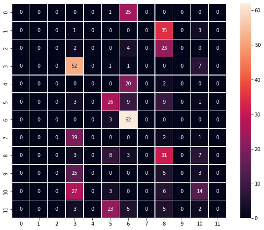

```python
# Obtaining the categorical values from y_test_encoded and y_pred
y_pred_arg=np.argmax(y_pred,axis=1)
y_test_arg=np.argmax(y_test_encoded,axis=1)

# Plotting the Confusion Matrix using confusion matrix() function which is also predefined tensorflow module
confusion_matrix = tf.math.confusion_matrix(y_test_arg,y_pred_arg)
f, ax = plt.subplots(figsize=(10, 8))
sns.heatmap(
    confusion_matrix,
    annot=True,
    linewidths=.4,
    fmt="d",
    square=True,
    ax=ax
)
plt.show()
```

Taking a look at the confusion matrix for Model 1 - the base CNN model, most of the target values are wrongly predicted. This could be because of the imbalanced data and the less number of convolution layers for training.

We can try building a model with data augumentation and batch normalization technique.

## CNN with Data Augumentation and Batch Normalization

```python
# Clearing backend
from tensorflow.keras import backend
backend.clear_session()

# Fixing the seed for random number generators
import random
np.random.seed(42)
random.seed(42)
tf.random.set_seed(42)
```

Although there are many ways to do data augumentation, we will only be using rotation and fill techniques here in this model

```python
# All images to be rescaled by 1/255.
train_datagen = ImageDataGenerator(
                              rotation_range=20,
                              fill_mode='nearest'
                              )
# test_datagen  = ImageDataGenerator(rescale = 1.0/255.)
```

```python
# Intializing a sequential model
model = Sequential()

# Adding first conv layer with 64 filters and kernel size 3x3 , padding 'same' provides the output size same as the input size
# Input_shape denotes input image dimension images
model.add(Conv2D(64, (3, 3), activation='relu', padding="same", input_shape=(64, 64, 3)))

# Adding max pooling to reduce the size of output of first conv layer
model.add(MaxPooling2D((2, 2), padding = 'same'))
# model.add(BatchNormalization())
model.add(Conv2D(32, (3, 3), activation='relu', padding="same"))
model.add(MaxPooling2D((2, 2), padding = 'same'))
model.add(BatchNormalization())
# flattening the output of the conv layer after max pooling to make it ready for creating dense connections
model.add(Flatten())

# Adding a fully connected dense layer with 100 neurons
model.add(Dense(16, activation='relu'))
model.add(Dropout(0.3))
# Adding the output layer with 10 neurons and activation functions as softmax since this is a multi-class classification problem
model.add(Dense(12, activation='softmax'))

# Using SGD Optimizer
# opt = SGD(learning_rate=0.01, momentum=0.9)
opt=Adam()
# Compile model
model.compile(optimizer=opt, loss='categorical_crossentropy', metrics=['accuracy'])

# Generating the summary of the model
model.summary()
```

```
Model: "sequential"
_________________________________________________________________
 Layer (type)                Output Shape              Param #
=================================================================
 conv2d (Conv2D)             (None, 64, 64, 64)        1792

 max_pooling2d (MaxPooling2D  (None, 32, 32, 64)       0
 )

 conv2d_1 (Conv2D)           (None, 32, 32, 32)        18464

 max_pooling2d_1 (MaxPooling  (None, 16, 16, 32)       0
 2D)

 batch_normalization (BatchN  (None, 16, 16, 32)       128
 ormalization)

 flatten (Flatten)           (None, 8192)              0

 dense (Dense)               (None, 16)                131088

 dropout (Dropout)           (None, 16)                0

 dense_1 (Dense)             (None, 12)                204

=================================================================
Total params: 151,676
Trainable params: 151,612
Non-trainable params: 64
_________________________________________________________________
```

```python
# Epochs
epochs = 25
# Batch size
batch_size = 64

history = model.fit(train_datagen.flow(X_train_normalized,y_train_encoded,
                                       batch_size=batch_size,
                                       seed=42,
                                       shuffle=False),
                    epochs=epochs,
                    steps_per_epoch=X_train_normalized.shape[0] // batch_size,
                    validation_data=(X_val_normalized,y_val_encoded),
                    verbose=1)
```

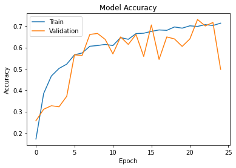

```python
plt.plot(history.history['accuracy'])
plt.plot(history.history['val_accuracy'])
plt.title('Model Accuracy')
plt.ylabel('Accuracy')
plt.xlabel('Epoch')
plt.legend(['Train', 'Validation'], loc='upper left')
plt.show()
```

Although the training accuracy and the validation accuracies are close at some instances and notably high - there is less overfitting, the validation accuracy is rapidly changing and hence would not be able to provide better predictions on the testing data

```python
accuracy = model.evaluate(X_test_normalized, y_test_encoded, verbose=2)
```

```
15/15 - 0s - loss: 1.9947 - accuracy: 0.4863 - 89ms/epoch - 6ms/step
```

The accuracy on the testing data with this model is 48%

```python
# Here we would get the output as probablities for each category
y_pred=model.predict(X_test_normalized)
```

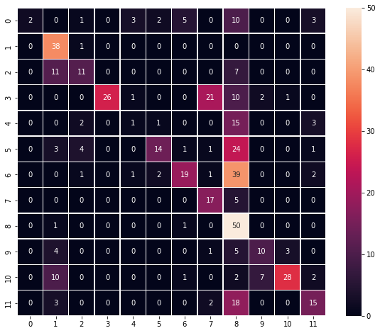

```python
# Obtaining the categorical values from y_test_encoded and y_pred
y_pred_arg=np.argmax(y_pred,axis=1)
y_test_arg=np.argmax(y_test_encoded,axis=1)

# Plotting the Confusion Matrix using confusion matrix() function which is also predefined tensorflow module
confusion_matrix = tf.math.confusion_matrix(y_test_arg,y_pred_arg)
f, ax = plt.subplots(figsize=(10, 8))
sns.heatmap(
    confusion_matrix,
    annot=True,
    linewidths=.4,
    fmt="d",
    square=True,
    ax=ax
)
plt.show()
```

We will try to incrporate some transfer learning models to see if we could improve the accuracy

## Transfer Learning Models

There are various models that we could apply for CNN, but for this particular type of task - image processing - we can look at 3 transfer models in this notebook.

- VGG16
- ResNet50
- VGG19

### VGG16 Model

```python
# Clearing backend
from tensorflow.keras import backend
backend.clear_session()
```

```python
from tensorflow.keras.models import Model
from keras.applications.vgg16 import VGG16

vgg_model = VGG16(weights='imagenet', include_top = False, input_shape = (64,64,3))
vgg_model.summary()
```

```
Model: "vgg16"
_________________________________________________________________
 Layer (type)                Output Shape              Param #
=================================================================
 input_1 (InputLayer)        [(None, 64, 64, 3)]       0

 block1_conv1 (Conv2D)       (None, 64, 64, 64)        1792

 block1_conv2 (Conv2D)       (None, 64, 64, 64)        36928

 block1_pool (MaxPooling2D)  (None, 32, 32, 64)        0

 block2_conv1 (Conv2D)       (None, 32, 32, 128)       73856

 block2_conv2 (Conv2D)       (None, 32, 32, 128)       147584

 block2_pool (MaxPooling2D)  (None, 16, 16, 128)       0

 block3_conv1 (Conv2D)       (None, 16, 16, 256)       295168

 block3_conv2 (Conv2D)       (None, 16, 16, 256)       590080

 block3_conv3 (Conv2D)       (None, 16, 16, 256)       590080

 block3_pool (MaxPooling2D)  (None, 8, 8, 256)         0

 block4_conv1 (Conv2D)       (None, 8, 8, 512)         1180160

 block4_conv2 (Conv2D)       (None, 8, 8, 512)         2359808

 block4_conv3 (Conv2D)       (None, 8, 8, 512)         2359808

 block4_pool (MaxPooling2D)  (None, 4, 4, 512)         0

 block5_conv1 (Conv2D)       (None, 4, 4, 512)         2359808

 block5_conv2 (Conv2D)       (None, 4, 4, 512)         2359808

 block5_conv3 (Conv2D)       (None, 4, 4, 512)         2359808

 block5_pool (MaxPooling2D)  (None, 2, 2, 512)         0

=================================================================
Total params: 14,714,688
Trainable params: 14,714,688
Non-trainable params: 0
_________________________________________________________________
```

The total weights that would need to be trained from the VGG16 model are 14,714,688 but because we are only importing and as the *not trainable* state, we will be importing the best weights from this model and we will use those weights direcly in our notebook

```python
# Making all the layers of the VGG model non-trainable. i.e. freezing them
for layer in vgg_model.layers:
    layer.trainable = False
```

```python
new_model = Sequential()

# Adding the convolutional part of the VGG16 model from above
new_model.add(vgg_model)

# Flattening the output of the VGG16 model because it is from a convolutional layer
new_model.add(Flatten())

# Adding a dense output layer
new_model.add(Dense(32, activation='relu'))
new_model.add(Dropout(0.2))
new_model.add(Dense(16, activation='relu'))
new_model.add(Dense(12, activation='softmax'))
opt=Adam()
# Compile model
new_model.compile(optimizer=opt, loss='categorical_crossentropy', metrics=['accuracy'])

# Generating the summary of the model
new_model.summary()
```

```
Model: "sequential"
_________________________________________________________________
 Layer (type)                Output Shape              Param #
=================================================================
 vgg16 (Functional)          (None, 2, 2, 512)         14714688

 flatten (Flatten)           (None, 2048)              0

 dense (Dense)               (None, 32)                65568

 dropout (Dropout)           (None, 32)                0

 dense_1 (Dense)             (None, 16)                528

 dense_2 (Dense)             (None, 12)                204

=================================================================
Total params: 14,780,988
Trainable params: 66,300
Non-trainable params: 14,714,688
_________________________________________________________________
```

As explained previously, because we are exporting the weights the total trainable parameters are reduced and is only 66,300 which is completely based on the Dense layers instead of the Convolutional layers

```python
# Epochs
epochs = 25
# Batch size
batch_size = 64

history_vgg16 = new_model.fit(train_datagen.flow(X_train_normalized,y_train_encoded,
                                       batch_size=batch_size,
                                       seed=42,
                                       shuffle=False),
                    epochs=epochs,
                    steps_per_epoch=X_train_normalized.shape[0] // batch_size,
                    validation_data=(X_val_normalized,y_val_encoded),
                    verbose=1)
```

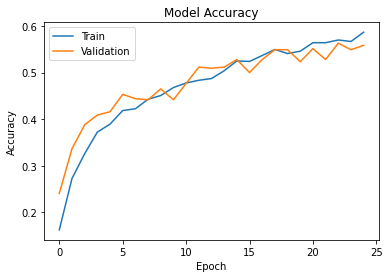

```python
plt.plot(history_vgg16.history['accuracy'])
plt.plot(history_vgg16.history['val_accuracy'])
plt.title('Model Accuracy')
plt.ylabel('Accuracy')
plt.xlabel('Epoch')
plt.legend(['Train', 'Validation'], loc='upper left')
plt.show()
```

The training accuracy and the validation accuracy seem to he high and very close to each other. Thus, this model has less overfitting issue and has the best accuracy for validation so far

```python
accuracy = new_model.evaluate(X_test_normalized, y_test_encoded, verbose=2)
```

```
15/15 - 0s - loss: 1.2556 - accuracy: 0.5684 - 309ms/epoch - 21ms/step
```

The accuracy on the tesiting data is also better compared to previous models at 56%

```python
# Here we would get the output as probablities for each category
y_pred=new_model.predict(X_test_normalized)
```

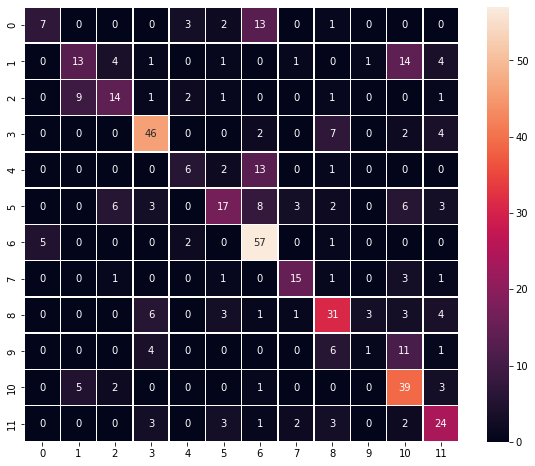

```python
# Obtaining the categorical values from y_test_encoded and y_pred
y_pred_arg=np.argmax(y_pred,axis=1)
y_test_arg=np.argmax(y_test_encoded,axis=1)

# Plotting the Confusion Matrix using confusion matrix() function which is also predefined tensorflow module
confusion_matrix = tf.math.confusion_matrix(y_test_arg,y_pred_arg)
f, ax = plt.subplots(figsize=(10, 8))
sns.heatmap(
    confusion_matrix,
    annot=True,
    linewidths=.4,
    fmt="d",
    square=True,
    ax=ax
)
plt.show()
```

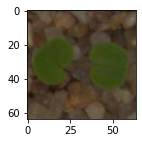

```
Predicted Label ['Small-flowered Cranesbill']
True Label Small-flowered Cranesbill
```

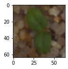

```
Predicted Label ['Cleavers']
True Label Cleavers
```

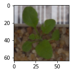

```
Predicted Label ['Small-flowered Cranesbill']
True Label Shepherds Purse
```

```python
# Visualizing the predicted and correct label of images from test data
plt.figure(figsize=(2,2))
plt.imshow(X_test[2])
plt.show()
print('Predicted Label', enc.inverse_transform(new_model.predict((X_test_normalized[2].reshape(1,64,64,3)))))   # reshaping the input image as we are only trying to predict using a single image
print('True Label', enc.inverse_transform(y_test_encoded)[2])                                               # using inverse_transform() to get the output label from the output vector

plt.figure(figsize=(2,2))
plt.imshow(X_test[33])
plt.show()
print('Predicted Label', enc.inverse_transform(new_model.predict((X_test_normalized[33].reshape(1,64,64,3)))))  # reshaping the input image as we are only trying to predict using a single image
print('True Label', enc.inverse_transform(y_test_encoded)[33])                                              # using inverse_transform() to get the output label from the output vector

plt.figure(figsize=(2,2))
plt.imshow(X_test[36])
plt.show()
print('Predicted Label', enc.inverse_transform(new_model.predict((X_test_normalized[36].reshape(1,64,64,3)))))  # reshaping the input image as we are only trying to predict using a single image
print('True Label', enc.inverse_transform(y_test_encoded)[36])
```

### Resnet50 model

```python
# Clearing backend
from tensorflow.keras import backend
backend.clear_session()
```

```python
from tensorflow.keras.models import Model
from tensorflow.keras.applications import ResNet50
```

```python
resnet50 = ResNet50(weights='imagenet', include_top = False, input_shape = (64,64,3))
resnet50.summary()
```

```
Model: "resnet50"
__________________________________________________________________________________________________
 Layer (type)                   Output Shape         Param #     Connected to
==================================================================================================
 input_1 (InputLayer)           [(None, 64, 64, 3)]  0           []

 conv1_pad (ZeroPadding2D)      (None, 70, 70, 3)    0           ['input_1[0][0]']

 conv1_conv (Conv2D)            (None, 32, 32, 64)   9472        ['conv1_pad[0][0]']

 conv1_bn (BatchNormalization)  (None, 32, 32, 64)   256         ['conv1_conv[0][0]']

 conv1_relu (Activation)        (None, 32, 32, 64)   0           ['conv1_bn[0][0]']

 pool1_pad (ZeroPadding2D)      (None, 34, 34, 64)   0           ['conv1_relu[0][0]']

 pool1_pool (MaxPooling2D)      (None, 16, 16, 64)   0           ['pool1_pad[0][0]']

 conv2_block1_1_conv (Conv2D)   (None, 16, 16, 64)   4160        ['pool1_pool[0][0]']

 conv2_block1_1_bn (BatchNormal  (None, 16, 16, 64)  256         ['conv2_block1_1_conv[0][0]']
 ization)

 conv2_block1_1_relu (Activatio  (None, 16, 16, 64)  0           ['conv2_block1_1_bn[0][0]']
 n)

 conv2_block1_2_conv (Conv2D)   (None, 16, 16, 64)   36928       ['conv2_block1_1_relu[0][0]']

 conv2_block1_2_bn (BatchNormal  (None, 16, 16, 64)  256         ['conv2_block1_2_conv[0][0]']
 ization)

 conv2_block1_2_relu (Activatio  (None, 16, 16, 64)  0           ['conv2_block1_2_bn[0][0]']
 n)

 conv2_block1_0_conv (Conv2D)   (None, 16, 16, 256)  16640       ['pool1_pool[0][0]']

 conv2_block1_3_conv (Conv2D)   (None, 16, 16, 256)  16640       ['conv2_block1_2_relu[0][0]']

 conv2_block1_0_bn (BatchNormal  (None, 16, 16, 256)  1024       ['conv2_block1_0_conv[0][0]']
 ization)
```

[output cut: 404 more lines]

```
 conv5_block3_3_conv (Conv2D)   (None, 2, 2, 2048)   1050624     ['conv5_block3_2_relu[0][0]']

 conv5_block3_3_bn (BatchNormal  (None, 2, 2, 2048)  8192        ['conv5_block3_3_conv[0][0]']
 ization)

 conv5_block3_add (Add)         (None, 2, 2, 2048)   0           ['conv5_block2_out[0][0]',
                                                                  'conv5_block3_3_bn[0][0]']

 conv5_block3_out (Activation)  (None, 2, 2, 2048)   0           ['conv5_block3_add[0][0]']

==================================================================================================
Total params: 23,587,712
Trainable params: 23,534,592
Non-trainable params: 53,120
__________________________________________________________________________________________________
```

```python
# Making all the layers of the VGG model non-trainable. i.e. freezing them
for layer in resnet50.layers:
    layer.trainable = False
```

```python
new_model = Sequential()

# Adding the convolutional part of the VGG16 model from above
new_model.add(resnet50)

# Flattening the output of the VGG16 model because it is from a convolutional layer
new_model.add(Flatten())

# Adding a dense output layer
new_model.add(Dense(32, activation='relu'))
new_model.add(Dropout(0.2))
new_model.add(Dense(16, activation='relu'))
new_model.add(Dense(12, activation='softmax'))
opt=Adam()
# Compile model
new_model.compile(optimizer=opt, loss='categorical_crossentropy', metrics=['accuracy'])

# Generating the summary of the model
new_model.summary()
```

```
Model: "sequential"
_________________________________________________________________
 Layer (type)                Output Shape              Param #
=================================================================
 resnet50 (Functional)       (None, 2, 2, 2048)        23587712

 flatten (Flatten)           (None, 8192)              0

 dense (Dense)               (None, 32)                262176

 dropout (Dropout)           (None, 32)                0

 dense_1 (Dense)             (None, 16)                528

 dense_2 (Dense)             (None, 12)                204

=================================================================
Total params: 23,850,620
Trainable params: 262,908
Non-trainable params: 23,587,712
_________________________________________________________________
```

```python
# Epochs
epochs = 25
# Batch size
batch_size = 64

history_vgg16 = new_model.fit(train_datagen.flow(X_train_normalized,y_train_encoded,
                                       batch_size=batch_size,
                                       seed=42,
                                       shuffle=False),
                    epochs=epochs,
                    steps_per_epoch=X_train_normalized.shape[0] // batch_size,
                    validation_data=(X_val_normalized,y_val_encoded),
                    verbose=1)
```

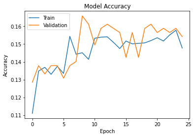

```python
plt.plot(history_vgg16.history['accuracy'])
plt.plot(history_vgg16.history['val_accuracy'])
plt.title('Model Accuracy')
plt.ylabel('Accuracy')
plt.xlabel('Epoch')
plt.legend(['Train', 'Validation'], loc='upper left')
plt.show()
```

The training accuracy and the validation accuracy are poor and the validation accuracy is not stable

```python
accuracy = new_model.evaluate(X_test_normalized, y_test_encoded, verbose=2)
```

```
15/15 - 1s - loss: 2.3709 - accuracy: 0.1558 - 634ms/epoch - 42ms/step
```

```python
# Here we would get the output as probablities for each category
y_pred=new_model.predict(X_test_normalized)
```

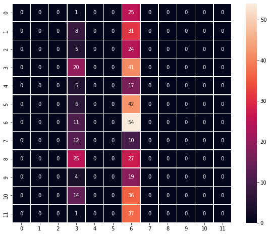

```python
# Obtaining the categorical values from y_test_encoded and y_pred
y_pred_arg=np.argmax(y_pred,axis=1)
y_test_arg=np.argmax(y_test_encoded,axis=1)

# Plotting the Confusion Matrix using confusion matrix() function which is also predefined tensorflow module
confusion_matrix = tf.math.confusion_matrix(y_test_arg,y_pred_arg)
f, ax = plt.subplots(figsize=(10, 8))
sns.heatmap(
    confusion_matrix,
    annot=True,
    linewidths=.4,
    fmt="d",
    square=True,
    ax=ax
)
plt.show()
```

This model predicts all the classes to be 6 or 3. Clearly this is a bad model for our kind of problem

### VGG19 Model

```python
# Clearing backend
from tensorflow.keras import backend
backend.clear_session()
```

```python
from tensorflow.keras.applications import VGG19

vgg19_model = VGG19(weights='imagenet', include_top = False, input_shape = (64,64,3))
vgg19_model.summary()
```

```
Downloading data from https://storage.googleapis.com/tensorflow/keras-applications/vgg19/vgg19_weights_tf_dim_ordering_tf_kernels_notop.h5
Model: "vgg19"
_________________________________________________________________
 Layer (type)                Output Shape              Param #
=================================================================
 input_1 (InputLayer)        [(None, 64, 64, 3)]       0

 block1_conv1 (Conv2D)       (None, 64, 64, 64)        1792

 block1_conv2 (Conv2D)       (None, 64, 64, 64)        36928

 block1_pool (MaxPooling2D)  (None, 32, 32, 64)        0

 block2_conv1 (Conv2D)       (None, 32, 32, 128)       73856

 block2_conv2 (Conv2D)       (None, 32, 32, 128)       147584

 block2_pool (MaxPooling2D)  (None, 16, 16, 128)       0

 block3_conv1 (Conv2D)       (None, 16, 16, 256)       295168

 block3_conv2 (Conv2D)       (None, 16, 16, 256)       590080

 block3_conv3 (Conv2D)       (None, 16, 16, 256)       590080

 block3_conv4 (Conv2D)       (None, 16, 16, 256)       590080

 block3_pool (MaxPooling2D)  (None, 8, 8, 256)         0

 block4_conv1 (Conv2D)       (None, 8, 8, 512)         1180160

 block4_conv2 (Conv2D)       (None, 8, 8, 512)         2359808

 block4_conv3 (Conv2D)       (None, 8, 8, 512)         2359808

 block4_conv4 (Conv2D)       (None, 8, 8, 512)         2359808

 block4_pool (MaxPooling2D)  (None, 4, 4, 512)         0

 block5_conv1 (Conv2D)       (None, 4, 4, 512)         2359808

 block5_conv2 (Conv2D)       (None, 4, 4, 512)         2359808

 block5_conv3 (Conv2D)       (None, 4, 4, 512)         2359808

 block5_conv4 (Conv2D)       (None, 4, 4, 512)         2359808

 block5_pool (MaxPooling2D)  (None, 2, 2, 512)         0

=================================================================
Total params: 20,024,384
Trainable params: 20,024,384
Non-trainable params: 0
_________________________________________________________________
```

```python
# Making all the layers of the VGG model non-trainable. i.e. freezing them
for layer in vgg19_model.layers:
    layer.trainable = False
```

```python
new_model = Sequential()

# Adding the convolutional part of the VGG16 model from above
new_model.add(vgg19_model)

# Flattening the output of the VGG16 model because it is from a convolutional layer
new_model.add(Flatten())

# Adding a dense output layer
new_model.add(Dense(32, activation='relu'))
new_model.add(Dropout(0.2))
new_model.add(Dense(16, activation='relu'))
new_model.add(Dense(12, activation='softmax'))
opt=Adam()
# Compile model
new_model.compile(optimizer=opt, loss='categorical_crossentropy', metrics=['accuracy'])

# Generating the summary of the model
new_model.summary()
```

```
Model: "sequential"
_________________________________________________________________
 Layer (type)                Output Shape              Param #
=================================================================
 vgg19 (Functional)          (None, 2, 2, 512)         20024384

 flatten (Flatten)           (None, 2048)              0

 dense (Dense)               (None, 32)                65568

 dropout (Dropout)           (None, 32)                0

 dense_1 (Dense)             (None, 16)                528

 dense_2 (Dense)             (None, 12)                204

=================================================================
Total params: 20,090,684
Trainable params: 66,300
Non-trainable params: 20,024,384
_________________________________________________________________
```

```python
# Epochs
epochs = 25
# Batch size
batch_size = 64

history_vgg16 = new_model.fit(train_datagen.flow(X_train_normalized,y_train_encoded,
                                       batch_size=batch_size,
                                       seed=42,
                                       shuffle=False),
                    epochs=epochs,
                    steps_per_epoch=X_train_normalized.shape[0] // batch_size,
                    validation_data=(X_val_normalized,y_val_encoded),
                    verbose=1)
```

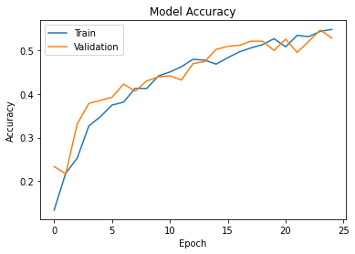

```python
plt.plot(history_vgg16.history['accuracy'])
plt.plot(history_vgg16.history['val_accuracy'])
plt.title('Model Accuracy')
plt.ylabel('Accuracy')
plt.xlabel('Epoch')
plt.legend(['Train', 'Validation'], loc='upper left')
plt.show()
```

The training accuracy and the validation accuracy does not show overfitting and is only a little lower than the VGG16 model accuracies.

```python
accuracy = new_model.evaluate(X_test_normalized, y_test_encoded, verbose=2)
```

```
15/15 - 0s - loss: 1.3576 - accuracy: 0.5200 - 237ms/epoch - 16ms/step
```

The testing accuracy with VGG19 is 52% which is slightly low compared to the VGG16 testing accuracy.

```python
# Here we would get the output as probablities for each category
y_pred=new_model.predict(X_test_normalized)
```

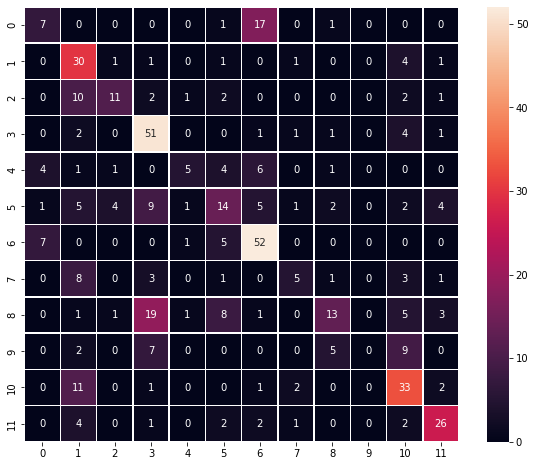

```python
# Obtaining the categorical values from y_test_encoded and y_pred
y_pred_arg=np.argmax(y_pred,axis=1)
y_test_arg=np.argmax(y_test_encoded,axis=1)

# Plotting the Confusion Matrix using confusion matrix() function which is also predefined tensorflow module
confusion_matrix = tf.math.confusion_matrix(y_test_arg,y_pred_arg)
f, ax = plt.subplots(figsize=(10, 8))
sns.heatmap(
    confusion_matrix,
    annot=True,
    linewidths=.4,
    fmt="d",
    square=True,
    ax=ax
)
plt.show()
```

## VGG16 Model with adjusted class weights

So far, from all the models we have seen the best model was the VGG16 with 56% accuracy on the testing data, which is still low. One possible reason for the low accuracy can be because of the class imbalance - so we will use the class_weight to alter the weights for each class such that the minority classes' weights are increased.

Since VGG16 was the best model so far, we will fit the data on the VGG16 model

```python
from sklearn.utils import class_weight

labelList = labels.Label.unique()
class_weights = class_weight.compute_class_weight(class_weight = "balanced",
                                                  classes = np.array(labelList),
                                                  y = y_train.values.reshape(-1)
                                                  )
class_weights = dict(zip(np.array(range(len(labelList))), class_weights))
#print calculated class weights
class_weights
```

```
{0: 0.7974709784411277,
 1: 0.8348524305555556,
 2: 1.714349376114082,
 3: 1.7909683426443204,
 4: 0.6476430976430977,
 5: 1.0145042194092826,
 6: 1.3818247126436782,
 7: 0.7669457735247209,
 8: 1.0275106837606838,
 9: 1.7909683426443204,
 10: 1.5050860719874803,
 11: 0.604874213836478}
```

```python
# Clearing backend
from tensorflow.keras import backend
backend.clear_session()
```

```python
vgg_model = VGG16(weights='imagenet', include_top = False, input_shape = (64,64,3))
vgg_model.summary()
```

```
Model: "vgg16"
_________________________________________________________________
 Layer (type)                Output Shape              Param #
=================================================================
 input_1 (InputLayer)        [(None, 64, 64, 3)]       0

 block1_conv1 (Conv2D)       (None, 64, 64, 64)        1792

 block1_conv2 (Conv2D)       (None, 64, 64, 64)        36928

 block1_pool (MaxPooling2D)  (None, 32, 32, 64)        0

 block2_conv1 (Conv2D)       (None, 32, 32, 128)       73856

 block2_conv2 (Conv2D)       (None, 32, 32, 128)       147584

 block2_pool (MaxPooling2D)  (None, 16, 16, 128)       0

 block3_conv1 (Conv2D)       (None, 16, 16, 256)       295168

 block3_conv2 (Conv2D)       (None, 16, 16, 256)       590080

 block3_conv3 (Conv2D)       (None, 16, 16, 256)       590080

 block3_pool (MaxPooling2D)  (None, 8, 8, 256)         0

 block4_conv1 (Conv2D)       (None, 8, 8, 512)         1180160

 block4_conv2 (Conv2D)       (None, 8, 8, 512)         2359808

 block4_conv3 (Conv2D)       (None, 8, 8, 512)         2359808

 block4_pool (MaxPooling2D)  (None, 4, 4, 512)         0

 block5_conv1 (Conv2D)       (None, 4, 4, 512)         2359808

 block5_conv2 (Conv2D)       (None, 4, 4, 512)         2359808

 block5_conv3 (Conv2D)       (None, 4, 4, 512)         2359808

 block5_pool (MaxPooling2D)  (None, 2, 2, 512)         0

=================================================================
Total params: 14,714,688
Trainable params: 14,714,688
Non-trainable params: 0
_________________________________________________________________
```

```python
# Making all the layers of the VGG model non-trainable. i.e. freezing them
for layer in vgg_model.layers:
    layer.trainable = False
```

```python
new_model = Sequential()

# Adding the convolutional part of the VGG16 model from above
new_model.add(vgg_model)

# Flattening the output of the VGG16 model because it is from a convolutional layer
new_model.add(Flatten())

# Adding a dense output layer
new_model.add(Dense(32, activation='relu'))
new_model.add(Dropout(0.2))
new_model.add(Dense(16, activation='relu'))
new_model.add(Dense(12, activation='softmax'))
opt=Adam()
# Compile model
new_model.compile(optimizer=opt, loss='categorical_crossentropy', metrics=['accuracy'])

# Generating the summary of the model
new_model.summary()
```

```
Model: "sequential"
_________________________________________________________________
 Layer (type)                Output Shape              Param #
=================================================================
 vgg16 (Functional)          (None, 2, 2, 512)         14714688

 flatten (Flatten)           (None, 2048)              0

 dense (Dense)               (None, 32)                65568

 dropout (Dropout)           (None, 32)                0

 dense_1 (Dense)             (None, 16)                528

 dense_2 (Dense)             (None, 12)                204

=================================================================
Total params: 14,780,988
Trainable params: 66,300
Non-trainable params: 14,714,688
_________________________________________________________________
```

```python
# Epochs
epochs = 30
# Batch size
batch_size = 64

history_vgg16 = new_model.fit(train_datagen.flow(X_train_normalized,y_train_encoded,
                                       batch_size=batch_size,
                                       seed=42,
                                       shuffle=False),
                    epochs=epochs,class_weight=class_weights,
                    steps_per_epoch=X_train_normalized.shape[0] // batch_size,
                    validation_data=(X_val_normalized,y_val_encoded),
                    verbose=1)
```

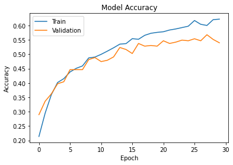

```python
plt.plot(history_vgg16.history['accuracy'])
plt.plot(history_vgg16.history['val_accuracy'])
plt.title('Model Accuracy')
plt.ylabel('Accuracy')
plt.xlabel('Epoch')
plt.legend(['Train', 'Validation'], loc='upper left')
plt.show()
```

```python
accuracy = new_model.evaluate(X_test_normalized, y_test_encoded, verbose=2)
```

```
15/15 - 0s - loss: 1.2411 - accuracy: 0.5874 - 189ms/epoch - 13ms/step
```

The accuracy on the testing data has also increased to 58% from 56% by adjusting class weights

```python
# Here we would get the output as probablities for each category
y_pred=new_model.predict(X_test_normalized)
```

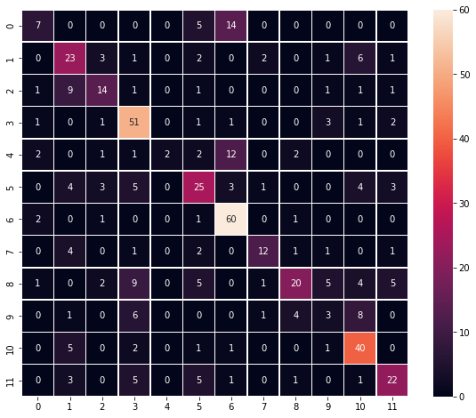

```python
# Obtaining the categorical values from y_test_encoded and y_pred
y_pred_arg=np.argmax(y_pred,axis=1)
y_test_arg=np.argmax(y_test_encoded,axis=1)

# Plotting the Confusion Matrix using confusion matrix() function which is also predefined tensorflow module
confusion_matrix = tf.math.confusion_matrix(y_test_arg,y_pred_arg)
f, ax = plt.subplots(figsize=(10, 8))
sns.heatmap(
    confusion_matrix,
    annot=True,
    linewidths=.4,
    fmt="d",
    square=True,
    ax=ax
)
plt.show()
```

The confusion matrix looks much better compared to the other models' confusion matrices

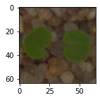

```
Predicted Label ['Small-flowered Cranesbill']
True Label Small-flowered Cranesbill
```

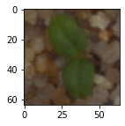

```
Predicted Label ['Cleavers']
True Label Cleavers
```

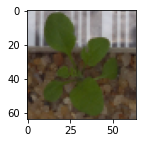

```
Predicted Label ['Small-flowered Cranesbill']
True Label Shepherds Purse
```

```python
# Visualizing the predicted and correct label of images from test data
plt.figure(figsize=(2,2))
plt.imshow(X_test[2])
plt.show()
print('Predicted Label', enc.inverse_transform(new_model.predict((X_test_normalized[2].reshape(1,64,64,3)))))   # reshaping the input image as we are only trying to predict using a single image
print('True Label', enc.inverse_transform(y_test_encoded)[2])                                               # using inverse_transform() to get the output label from the output vector

plt.figure(figsize=(2,2))
plt.imshow(X_test[33])
plt.show()
print('Predicted Label', enc.inverse_transform(new_model.predict((X_test_normalized[33].reshape(1,64,64,3)))))  # reshaping the input image as we are only trying to predict using a single image
print('True Label', enc.inverse_transform(y_test_encoded)[33])                                              # using inverse_transform() to get the output label from the output vector

plt.figure(figsize=(2,2))
plt.imshow(X_test[36])
plt.show()
print('Predicted Label', enc.inverse_transform(new_model.predict((X_test_normalized[36].reshape(1,64,64,3)))))  # reshaping the input image as we are only trying to predict using a single image
print('True Label', enc.inverse_transform(y_test_encoded)[36])
```

```python
pd.DataFrame({'Models':['Base CNN Model','CNN Model with Data Augmentation','VGG_16', 'ResNet50', 'VGG_19', 'VGG_16 with adjusted class weights'],'Train Accuracy':['30.60%','71.40%','58.66%','14.78%','54.80%','62.20%'],'Validation Accuracy':['41.12%','49.77%','55.84%','15.42%','52.80%','53.97%'],'Test Accuracy':['38.95%','48.63%','56.84%','15.58%','52%','58.75%']})
```

|  | Models | Train Accuracy | Validation Accuracy | Test Accuracy |
| --- | --- | --- | --- | --- |
| 0 | Base CNN Model | 30.60% | 41.12% | 38.95% |
| 1 | CNN Model with Data Augmentation | 71.40% | 49.77% | 48.63% |
| 2 | VGG_16 | 58.66% | 55.84% | 56.84% |
| 3 | ResNet50 | 14.78% | 15.42% | 15.58% |
| 4 | VGG_19 | 54.80% | 52.80% | 52% |
| 5 | VGG_16 with adjusted class weights | 62.20% | 53.97% | 58.75% |

## Conclusion

We tried 6 models on the Plant Seedlings dataset and the maximum test accuracy was found with the **VGG16 model with adjusted class weights** with the accuracy value of about 58%

This accuracy value is still low and could be improved. The follwing ideas/techniques can be tried to improve the accuracy:

- Although data augmentation was used, it was not completely used. Hence, we could explore more on the data augmentation to balance out the data first before building models.
- The number of layers could be increased but it also comes with a cost - increased computational time.
- The image can be preprocessed better:
  - Most of the images have the plant samplings on the center - so techniques like image cropping could be helpful in leave out some pixel information and concentrating more on the subject
  - Although the subject was clearly distinguishable from the background, the bakground still had a green shade which is same as the plant. Hence, this would have impacted the weight calculation. So, any color filtering technique to distinguish the subject might be useful